# LSTAT2340 - Analyse de données transcriptomique : RNA-SEQ : NGS illumina

Jerome Ambroise - UCL - IREC - CTMA

Februar 22, 2021,13:18

Dans le document, ci dessous, nous allons analyser des données NGS générées avec une plateforme Illumina.

Les données proviennent du prolongement de l’étude “MicroArray Quality Control (MAQC) project” appelée SEQC. Dans ce document, nous analysons 5 échantillons A (A1, A2, A3, A4 et A5) et 5 échantillons B (B1, B2, B3, B4 et B5) et l’objectif est d’identifier les gènes qui sont modulés.

# 1 Chargement des packages et importation des données.

Nous commençons par charger le package edger. edger est un package bioconductor qui dispose d’un “user guide” très complet.

```r
library(edgeR)
library(org.Hs.eg.db)
```

Nous chargeons ensuite les données. On va créer une DGElist. Cette DGElist a besoin de 3 informations:

- la matrice de comptage
- les noms des gènes
- les groupes (phénotypes)

```r
rm(list=ls())
expression <- read.table('1-data/ILM/ILM.txt')
head(expression)
```

```
##    EntrezID Symbol A_1_L01_FlowCellA A_2_L01_FlowCellA A_3_L01_FlowCellA
## 3     29974   A1CF                21                33                26
## 6         2    A2M              2683              2212              2769
## 7    144568  A2ML1                 4                 1                 1
## 8         3  A2MP1                 1                 0                 2
## 9     53947 A4GALT                44                34                35
## 10    51146  A4GNT                 1                 0                 0
##    A_4_L01_FlowCellA A_5_L01_FlowCellA B_1_L01_FlowCellA B_2_L01_FlowCellA
## 3                 34                31                 0                 0
## 6               3344              2803               911               841
## 7                  2                 5                12                13
## 8                  3                 1                 1                 5
## 9                 38                36                34                31
## 10                 0                 0                 1                 0
##    B_3_L01_FlowCellA B_4_L01_FlowCellA B_5_L01_FlowCellB
## 3                  0                 0                 0
## 6                960               753               597
## 7                 12                 7                14
## 8                  5                 2                 6
## 9                 22                28                10
## 10                 0                 1                 1
```

```r
keytypes(org.Hs.eg.db)
```

```
##  [1] "ACCNUM"       "ALIAS"        "ENSEMBL"      "ENSEMBLPROT"  "ENSEMBLTRANS"
##  [6] "ENTREZID"     "ENZYME"       "EVIDENCE"     "EVIDENCEALL"  "GENENAME"
## [11] "GO"           "GOALL"        "IPI"          "MAP"          "OMIM"
## [16] "ONTOLOGY"     "ONTOLOGYALL"  "PATH"         "PFAM"         "PMID"
## [21] "PROSITE"      "REFSEQ"       "SYMBOL"       "UCSCKG"       "UNIGENE"
## [26] "UNIPROT"
```

```r
SYMBOL <- mapIds(org.Hs.eg.db, keys=as.character(expression$EntrezID),keytype="ENTREZID", column="SYMBOL")
ENSEMBL <- mapIds(org.Hs.eg.db, keys=as.character(expression$EntrezID),keytype="ENTREZID", column="ENSEMBL")
genes <- data.frame(expression[,1:2],SYMBOL,ENSEMBL)
head(genes)
```

```
##    EntrezID Symbol SYMBOL         ENSEMBL
## 3     29974   A1CF   A1CF ENSG00000148584
## 6         2    A2M    A2M ENSG00000175899
## 7    144568  A2ML1  A2ML1 ENSG00000166535
## 8         3  A2MP1  A2MP1 ENSG00000256069
## 9     53947 A4GALT A4GALT ENSG00000128274
## 10    51146  A4GNT  A4GNT ENSG00000118017
```

```r
group <- c(rep('A',5),rep('B',5))
dge <- DGEList(counts=expression[,-c(1,2)],group=group,genes =genes )
```

# 2 Filtre sur les gènes faiblement exprimés et normalisation des données

```r
dge
```

```
## An object of class "DGEList"
## $counts
##   A_1_L01_FlowCellA A_2_L01_FlowCellA A_3_L01_FlowCellA A_4_L01_FlowCellA
## 3                21                33                26                34
## 6              2683              2212              2769              3344
## 7                 4                 1                 1                 2
## 8                 1                 0                 2                 3
## 9                44                34                35                38
##   A_5_L01_FlowCellA B_1_L01_FlowCellA B_2_L01_FlowCellA B_3_L01_FlowCellA
## 3                31                 0                 0                 0
## 6              2803               911               841               960
## 7                 5                12                13                12
## 8                 1                 1                 5                 5
## 9                36                34                31                22
##   B_4_L01_FlowCellA B_5_L01_FlowCellB
## 3                 0                 0
## 6               753               597
## 7                 7                14
## 8                 2                 6
## 9                28                10
## 19788 more rows ...
##
## $samples
##                   group lib.size norm.factors
## A_1_L01_FlowCellA     A  3309045            1
## A_2_L01_FlowCellA     A  2768691            1
## A_3_L01_FlowCellA     A  3440870            1
## A_4_L01_FlowCellA     A  3938889            1
## A_5_L01_FlowCellA     A  3414075            1
## B_1_L01_FlowCellA     B  3968046            1
## B_2_L01_FlowCellA     B  3851746            1
## B_3_L01_FlowCellA     B  4166623            1
## B_4_L01_FlowCellA     B  3150904            1
## B_5_L01_FlowCellB     B  2573246            1
##
## $genes
##   EntrezID Symbol SYMBOL         ENSEMBL
## 3    29974   A1CF   A1CF ENSG00000148584
## 6        2    A2M    A2M ENSG00000175899
## 7   144568  A2ML1  A2ML1 ENSG00000166535
## 8        3  A2MP1  A2MP1 ENSG00000256069
## 9    53947 A4GALT A4GALT ENSG00000128274
## 19788 more rows ...
```

```r
keep <- rowSums(cpm(dge)>1) >= 2
dge <- dge[keep, , keep.lib.sizes=FALSE]
dge <- calcNormFactors(dge)
dge
```

```
## An object of class "DGEList"
## $counts
##   A_1_L01_FlowCellA A_2_L01_FlowCellA A_3_L01_FlowCellA A_4_L01_FlowCellA
## 3                21                33                26                34
## 6              2683              2212              2769              3344
## 7                 4                 1                 1                 2
## 8                 1                 0                 2                 3
## 9                44                34                35                38
##   A_5_L01_FlowCellA B_1_L01_FlowCellA B_2_L01_FlowCellA B_3_L01_FlowCellA
## 3                31                 0                 0                 0
## 6              2803               911               841               960
## 7                 5                12                13                12
## 8                 1                 1                 5                 5
## 9                36                34                31                22
##   B_4_L01_FlowCellA B_5_L01_FlowCellB
## 3                 0                 0
## 6               753               597
## 7                 7                14
## 8                 2                 6
## 9                28                10
## 15261 more rows ...
##
## $samples
##                   group lib.size norm.factors
## A_1_L01_FlowCellA     A  3307525    1.0935962
## A_2_L01_FlowCellA     A  2767470    1.1113357
## A_3_L01_FlowCellA     A  3439275    1.0986896
## A_4_L01_FlowCellA     A  3937150    1.0966815
## A_5_L01_FlowCellA     A  3412467    1.1045716
## B_1_L01_FlowCellA     B  3966464    0.9024897
## B_2_L01_FlowCellA     B  3850164    0.9054026
## B_3_L01_FlowCellA     B  4164872    0.9117774
## B_4_L01_FlowCellA     B  3149611    0.9117153
## B_5_L01_FlowCellB     B  2572182    0.9101570
##
## $genes
##   EntrezID Symbol SYMBOL         ENSEMBL
## 3    29974   A1CF   A1CF ENSG00000148584
## 6        2    A2M    A2M ENSG00000175899
## 7   144568  A2ML1  A2ML1 ENSG00000166535
## 8        3  A2MP1  A2MP1 ENSG00000256069
## 9    53947 A4GALT A4GALT ENSG00000128274
## 15261 more rows ...
```

# 3 Création des modèles statistiques pour détecter les gènes modulés

Pour rappel, le but est de comparer les niveaux d’expression de chacun des gènes entre les 5 échantillons ‘A’ et les 5 échantillons ‘B’. Nous commencçons par spécifier à R le design de notre expérience

```r
design <- model.matrix(~dge$sample$group)
design
```

```
##    (Intercept) dge$sample$groupB
## 1            1                 0
## 2            1                 0
## 3            1                 0
## 4            1                 0
## 5            1                 0
## 6            1                 1
## 7            1                 1
## 8            1                 1
## 9            1                 1
## 10           1                 1
## attr(,"assign")
## [1] 0 1
## attr(,"contrasts")
## attr(,"contrasts")$`dge$sample$group`
## [1] "contr.treatment"
```

```r
dge <- estimateDisp(dge,design)

fit <- glmQLFit(dge,design)
qlf <- glmQLFTest(fit,coef=2)
```

# 4 5: Ecriture des résultats

```r
topTags(qlf)
```

```
## Coefficient:  dge$sample$groupB
##       EntrezID  Symbol  SYMBOL         ENSEMBL      logFC    logCPM        F
## 13600     2670    GFAP    GFAP ENSG00000131095  11.379226 11.708377 20974.15
## 43464     6616  SNAP25  SNAP25 ENSG00000132639   9.719129 11.082353 14618.32
## 826        338    APOB    APOB ENSG00000084674  -9.967457  9.809281 12943.46
## 9871     23017   FAIM2   FAIM2 ENSG00000135472   9.371222  9.564305 11790.43
## 509        213     ALB     ALB ENSG00000163631 -10.124870  9.749811 11721.07
## 25986     4155     MBP     MBP ENSG00000197971   6.826806 10.700792 11551.67
## 19397     3798   KIF5A   KIF5A ENSG00000155980   6.938498 10.171168 11482.71
## 9901     11170 FAM107A FAM107A ENSG00000168309   9.177601  9.263402 11461.64
## 4608    222166 C7ORF41   MTURN ENSG00000180354   5.573166 10.150075 11213.91
## 28748    65009   NDRG4   NDRG4 ENSG00000103034   7.303237  9.710125 10764.58
##             PValue          FDR
## 13600 4.218150e-47 6.439427e-43
## 43464 1.439958e-44 1.099120e-40
## 826   1.027526e-43 5.228739e-40
## 9871  4.634597e-43 1.396112e-39
## 509   5.097720e-43 1.396112e-39
## 25986 6.448148e-43 1.396112e-39
## 19397 7.102557e-43 1.396112e-39
## 9901  7.316192e-43 1.396112e-39
## 4608  1.041037e-42 1.765830e-39
## 28748 2.014252e-42 3.074957e-39
```

```r
log2fc <- qlf$table[,1]
pvalue <- qlf$table[,4]
adj.pvalue <- p.adjust(pvalue,method='BH')
result <- data.frame(qlf$genes,log2fc,pvalue,adj.pvalue)
result <- result[sort.list(result$adj.pvalue),]
head(result)
```

```
##       EntrezID  Symbol  SYMBOL         ENSEMBL     log2fc       pvalue
## 13600     2670    GFAP    GFAP ENSG00000131095  11.379226 4.218150e-47
## 43464     6616  SNAP25  SNAP25 ENSG00000132639   9.719129 1.439958e-44
## 826        338    APOB    APOB ENSG00000084674  -9.967457 1.027526e-43
## 509        213     ALB     ALB ENSG00000163631 -10.124870 5.097720e-43
## 9871     23017   FAIM2   FAIM2 ENSG00000135472   9.371222 4.634597e-43
## 9901     11170 FAM107A FAM107A ENSG00000168309   9.177601 7.316192e-43
##         adj.pvalue
## 13600 6.439427e-43
## 43464 1.099120e-40
## 826   5.228739e-40
## 509   1.396112e-39
## 9871  1.396112e-39
## 9901  1.396112e-39
```

# 5 6: Quelques graphiques

## 5.1 6.1 Heatmap

Nous allons représenter une heatmap des 100 premiers gènes (choix arbitraire des gènes).

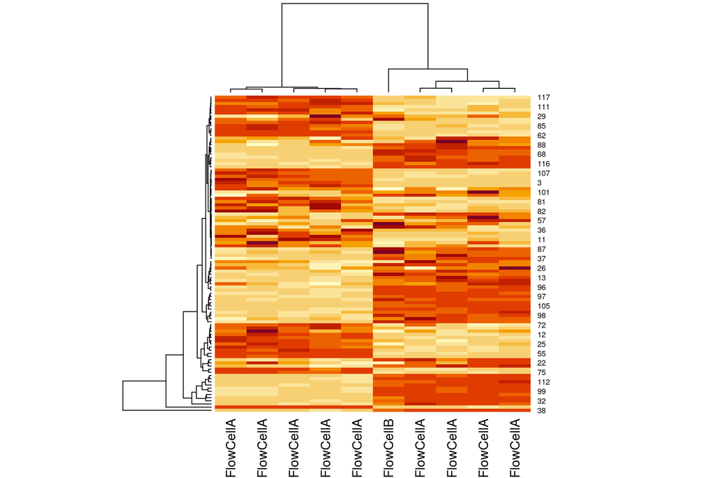

```r
heatmap(as.matrix(cpm(dge,normalized.lib.sizes=TRUE, log=FALSE, prior.count=0.25))[1:100,])
```

## 5.2 6.2 Volcano

Nous allons représenter un volcano-plot.

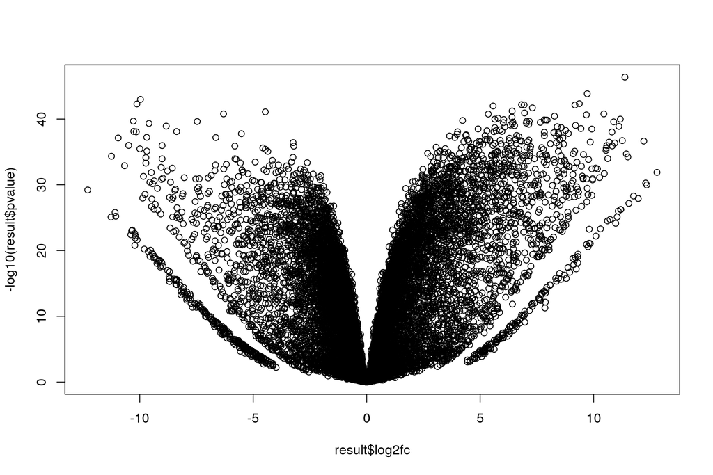

```r
plot(result$log2fc,-log10(result$pvalue))
```